# Text mining, sentiment analysis, and visualization

### Sentiment analysis

In the following, we will use Sentida to find sentiment scores of the entire text and individual words. Since an encomium is made to honour someone, we should expect the general sentiment to be quite positive.

```r
# We will start by finding the total and mean sentiment scores for the encomium

encomium_total_sent <- sentida(iconv(encomium_no_numeric,"latin1", "UTF-8") , output = "total")
encomium_mean_sent <- sentida(iconv(encomium_no_numeric,"latin1", "UTF-8") , output = "mean")

encomium_total_sent
```

```
## [1] 166.3827
```

```r
encomium_mean_sent
```

```
## [1] 0.2203744
```

The mean tells us that the encomium in general is slightly more positive than negative. This was expected due to the genre demanding praise of someone, though it is surprising that the sentiment value isn’t more positive than 0.22. Let’s try finding the sentiment value of each individual word.

Let’s find some counts (by sentiment ranking):

[figure not shown]

```r
# We will start by making a data frame with the sentiment for each word in our 'encomium_no_numeric' tibble.
# Firstly, we need a vector:

encomium_word_list <- encomium_no_numeric$group


# Now we can make a data frame that has the total sentiment value for each word using Sentida (lines 209-212 were partly generated by ChatGPT-5.5)

encomium_word_sent <- do.call(rbind,lapply(encomium_word_list,function(o) {
  x <- sentida(iconv(o,"latin1","UTF-8"),output="total")
  data.frame(ord=o,total=x)
}))


# Let's try plotting this with ggplot. We will order them based on their total sentiment value:

encomium_word_sent %>%
  ggplot(aes(x = reorder(ord, total), y = total)) +
  geom_col() +
  coord_flip() +
  theme_bw()
```

There are **a lot** of 0 value words that simply aren’t in Sentida’s lexicon. It is also very cluttered. Let us filter away the 0 value words, count only the top 20 of both positive and negative words, and color them depending on if they have a positive or negative value:

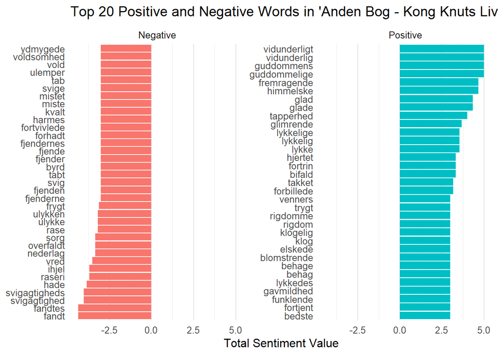

```r
# Lines 229-245 were partly generated by ChatGPT-5.5
top20_sent_encomium_vis <- encomium_word_sent %>%
  filter(total != 0) %>%
  mutate(sentiment = ifelse(total > 0, "Positive", "Negative")) %>%
  group_by(sentiment) %>%
  slice_max(abs(total), n = 20) %>%
  ungroup() %>%
  arrange(total) %>%
  mutate(ord = factor(ord, levels = ord)) %>%
  ggplot(aes(x = ord, y = total, fill = sentiment)) +
  geom_col(show.legend = FALSE) +
  coord_flip() +
  facet_wrap(~sentiment, scales = "free_y") +
  labs(title = "Top 20 Positive and Negative Words in 'Anden Bog - Kong Knuts Liv og Gerninger'",
    x = NULL,
    y = "Total Sentiment Value") +
  theme_minimal(base_size = 12) +
  theme(panel.grid.major.y=element_blank())
top20_sent_encomium_vis
```

```r
ggsave("figures/top20_sent_encomium.png", top20_sent_encomium_vis, width = 10, height = 5)
```

The positive words do in fact seem very positive. The top two negative words seem weird. Let’s cross-check this by individually trying the words in sentida.

```r
# So apparently "fandt" and "fandtes" are the absolute most negative words according to Sentida? That seems weird. We will try using Sentida to measure the total sentiment value of both these words individually:

sentida("fandt",output="total")
```

```
## [1] -4.333333
```

```r
sentida("fandtes",output="total")
```

```
## [1] -4.333333
```

```r
# Apparently yes, Sentida finds the past tenses of "finde" (Eng: "find") to be negative. Let's see if it finds "finde" or "fundet" (which is the past participle) negative too:

sentida("finde",output="total")
```

```
## [1] 0.6666667
```

```r
sentida("fundet",output="total")
```

```
## [1] 0
```

```r
# No. For some reason Sentida simply finds the past tense negative
```

It seems weird for “fandt” and “fandtes” to be that negative. It might be because being found is bad. Even then, being the absolute most negative word (ahead of “hade” and “ihjel) seems too much.